# ProblemSet4-4

PREDICTING EARNINGS FROM CENSUS DATA

The United States government periodically collects demographic information by conducting a census.

In this problem, we are going to use census information about an individual to predict how much a person earns – in particular, whether the person earns more than $50,000 per year. This data comes from the UCI Machine Learning Repository.

The file census.csv contains 1994 census data for almost 32,000 individuals in the United States.

The available variables include:

age = the age of the individual in years workclass = the classification of the individual's working status (does the person work for the federal government, work for the local government, work without pay, and so on) education = the level of education of the individual (e.g., 5th-6th grade, high school graduate, PhD, so on) maritalstatus = the marital status of the individual occupation = the type of work the individual does (e.g., administrative/clerical work, farming/fishing, sales and so on) relationship = relationship of individual to his/her household race = the individual's race sex = the individual's sex capitalgain = the capital gains of the individual in 1994 (from selling an asset such as a stock or bond for more than the original purchase price) capitalloss = the capital losses of the individual in 1994 (from selling an asset such as a stock or bond for less than the original purchase price) hoursperweek = the number of hours the individual works per week nativecountry = the native country of the individual over50k = whether or not the individual earned more than $50,000 in 1994

## PROBLEM 1.1 - A LOGISTIC REGRESSION MODEL (1 point possible)

As we did in lecture, let's begin by building a logistic regression model to predict whether an individual's earnings are above $50,000 using the other variables. First, read the dataset census.csv into R.

```r
census <- read.csv(file.choose())
```

Then, split the data randomly into a training set and a testing set, setting the seed to 2000 before creating the split. Split the data so that the training set contains 60% of the observations, while the testing set contains 40% of the observations.

```r
library(caTools)
set.seed(2000)
split = sample.split(census$over50k, SplitRatio = 0.6)
train = subset(census, split = T)
test = subset(census, split = F)
```

Next, build a logistic regression model using all of the independent variables to predict the dependent variable “over50k”, and use the training set to build the model.

```r
logModel0 <- glm(over50k ~ ., data = train, family = "binomial")
```

```
## Warning: glm.fit: fitted probabilities numerically 0 or 1 occurred
```

Which variables are significant, or have factors that are significant? (Use 0.1 as your significance threshold, so variables with a period or dot in the stars column should be counted too. You might see a warning message here - ignore it.)

```r
summary(logModel0)
```

```
##
## Call:
## glm(formula = over50k ~ ., family = "binomial", data = train)
##
## Deviance Residuals:
##    Min      1Q  Median      3Q     Max
## -5.068  -0.504  -0.182  -0.025   3.778
##
## Coefficients: (2 not defined because of singularities)
##                                           Estimate Std. Error z value
## (Intercept)                              -7.54e+00   7.60e-01   -9.93
## age                                       2.51e-02   1.66e-03   15.09
## workclass Federal-gov                     1.12e+00   1.55e-01    7.23
## workclass Local-gov                       4.21e-01   1.41e-01    2.98
## workclass Never-worked                   -1.05e+01   2.71e+02   -0.04
## workclass Private                         6.16e-01   1.26e-01    4.88
## workclass Self-emp-inc                    7.83e-01   1.51e-01    5.18
## workclass Self-emp-not-inc                1.20e-01   1.38e-01    0.87
## workclass State-gov                       2.95e-01   1.53e-01    1.93
## workclass Without-pay                    -1.22e+01   1.98e+02   -0.06
## education 11th                            8.62e-02   2.12e-01    0.41
## education 12th                            4.92e-01   2.71e-01    1.82
## education 1st-4th                        -4.65e-01   4.92e-01   -0.94
## education 5th-6th                        -3.37e-01   3.41e-01   -0.99
## education 7th-8th                        -5.41e-01   2.38e-01   -2.28
## education 9th                            -2.33e-01   2.65e-01   -0.88
## education Assoc-acdm                      1.33e+00   1.78e-01    7.48
## education Assoc-voc                       1.34e+00   1.71e-01    7.84
## education Bachelors                       1.94e+00   1.59e-01   12.21
## education Doctorate                       3.02e+00   2.18e-01   13.82
## education HS-grad                         8.11e-01   1.55e-01    5.25
## education Masters                         2.30e+00   1.69e-01   13.56
## education Preschool                      -2.08e+01   3.08e+02   -0.07
## education Prof-school                     2.86e+00   2.03e-01   14.09
## education Some-college                    1.15e+00   1.57e-01    7.36
## educationnum                                    NA         NA      NA
## maritalstatus Married-AF-spouse           2.68e+00   5.57e-01    4.81
## maritalstatus Married-civ-spouse          2.20e+00   2.70e-01    8.13
## maritalstatus Married-spouse-absent       1.33e-02   2.35e-01    0.06
## maritalstatus Never-married              -4.86e-01   8.84e-02   -5.50
```

[output cut: 164 more lines]

```
## nativecountry Thailand                    0.06639 .
## nativecountry Trinadad&Tobago             0.12091
## nativecountry United-States               0.10318
## nativecountry Vietnam                     0.00341 **
## nativecountry Yugoslavia                  0.58299
## ---
## Signif. codes:  0 '***' 0.001 '**' 0.01 '*' 0.05 '.' 0.1 ' ' 1
##
## (Dispersion parameter for binomial family taken to be 1)
##
##     Null deviance: 35292  on 31977  degrees of freedom
## Residual deviance: 20181  on 31881  degrees of freedom
## AIC: 20375
##
## Number of Fisher Scoring iterations: 13
```

## PROBLEM 1.2 - A LOGISTIC REGRESSION MODEL (1 point possible)

What is the accuracy of the model on the testing set? Use a threshold of 0.5. (You might see a warning message when you make predictions on the test set - you can safely ignore it.)

```r
logModel0Pred <- predict(logModel0, newdata = test, type = "response")
```

```
## Warning: prediction from a rank-deficient fit may be misleading
```

```r
table(test$over50k, logModel0Pred >= 0.5)
```

```
##
##          FALSE  TRUE
##    <=50K 22623  1660
##    >50K   3051  4644
```

```r
(22623 + 4644)/(nrow(test))
```

```
## [1] 0.8527
```

## PROBLEM 1.3 - A LOGISTIC REGRESSION MODEL (1 point possible)

What is the baseline accuracy for the testing set?

```r
table(test$over50k)[1]/(nrow(test))
```

```
##  <=50K
## 0.7594
```

## PROBLEM 1.4 - A LOGISTIC REGRESSION MODEL (1 point possible)

What is the area-under-the-curve (AUC) for this model on the test set?

```r
library(ROCR)
```

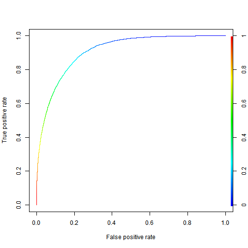

```r
ROCRpred = prediction(logModel0Pred, test$over50k)
ROCRperf = performance(ROCRpred, "tpr", "fpr")
plot(ROCRperf, colorize = TRUE)
```

```r
ROCRauc = performance(ROCRpred, "auc")
ROCRauc
```

```
## An object of class "performance"
## Slot "x.name":
## [1] "None"
##
## Slot "y.name":
## [1] "Area under the ROC curve"
##
## Slot "alpha.name":
## [1] "none"
##
## Slot "x.values":
## list()
##
## Slot "y.values":
## [[1]]
## [1] 0.909
##
##
## Slot "alpha.values":
## list()
```

## PROBLEM 2.1 - A CART MODEL (1 point possible)

We have just seen how the logistic regression model for this data achieves a high accuracy. Moreover, the significances of the variables give us a way to gauge which variables are relevant for this prediction task. However, it is not immediately clear which variables are more important than the others, especially due to the large number of factor variables in this problem.

Let us now build a classification tree for this model. Using the same training set, fit a CART model, and plot the tree. Use the default parameters, so don't set a value for minbucket or cp. Remember to specify method=“class” as an argument to rpart, since this is a classification problem.

How many splits does the tree have in total?

```r
library(rpart)
```

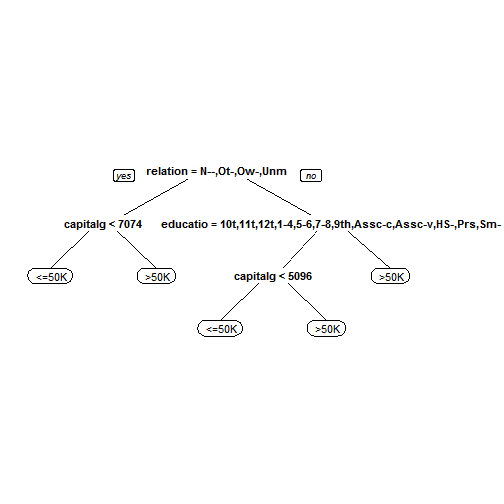

```r
library(rpart.plot)
CARTModel0 <- rpart(over50k ~ ., data = train)
prp(CARTModel0)
```

## PROBLEM 2.2 - A CART MODEL (1 point possible)

Which variable does the tree split on at the first level (the very first split of the tree)?

ANS Relation

## PROBLEM 2.3 - A CART MODEL (1 point possible)

Which variables does the tree split on at the second level (immediately after the first split of the tree)?

ANS education capitalgain

## PROBLEM 2.4 - A CART MODEL (1 point possible)

What is the accuracy of the model on the testing set? (Use a threshold of 0.5, so add the argument type=“class”.)

```r
CARTModel0Pred <- predict(CARTModel0, newdata = test, type = "class")
table(test$over50k, CARTModel0Pred)
```

```
##         CARTModel0Pred
##           <=50K  >50K
##    <=50K  23087  1196
##    >50K    3766  3929
```

```r
(23087 + 3929)/sum(table(test$over50k, CARTModel0Pred))
```

```
## [1] 0.8448
```

This highlights a very regular phenomenon when comparing CART and logistic regression. CART often performs a little worse than logistic regression in out-of-sample accuracy. However, as is the case here, the CART model is often much simpler to describe and understand.

## PROBLEM 2.5 - A CART MODEL (1 point possible)

Let us now consider the ROC curve and AUC for the CART model. Plot the ROC curve for the CART model you have estimated. Observe that compared to the logistic regression ROC curve, the CART ROC curve is less smooth than the logistic regression ROC curve. Which of the following explanations for this behavior is most correct? (HINT: Think about what the ROC curve is plotting and what changing the threshold does.)

```r
PredictROC = predict(CARTModel0, newdata = test)
PredictROC
```

[output not shown]

[output cut: 31964 more lines]

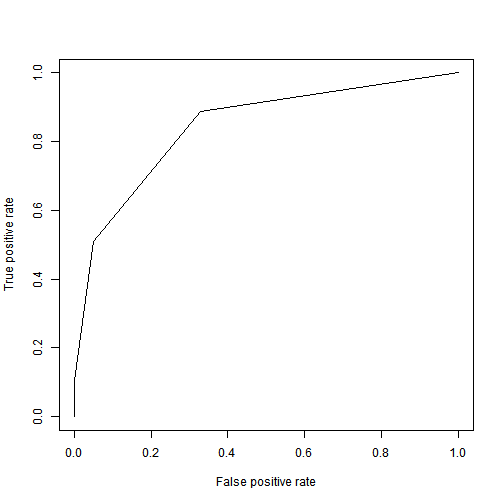

```r
pred = prediction(PredictROC[, 2], test$over50k)
perf = performance(pred, "tpr", "fpr")
plot(perf)
```

ANS The probabilities from the CART model take only a handful of values (five, one for each end bucket/leaf of the tree); the changes in the ROC curve correspond to setting the threshold to one of those values.